# 4

# using the silhouette method to remove the outliers,the ideal value of k was likewise found to be 2.

# Hence,we can consider the optimal number of k using the Elbow method.

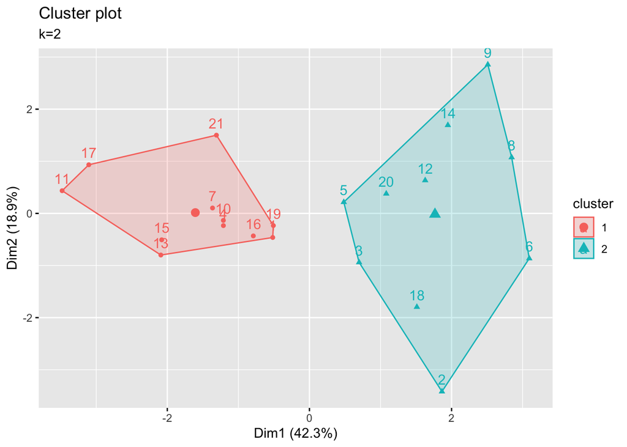

```r
#k=2
k_mean_model2<-kmeans(Mdata1,centers=2,nstart=25)
fviz_cluster(k_mean_model2,data=Mdata1)+labs(subtitle="k=2")
```

```r
k_mean_model2
```

```
## K-means clustering with 2 clusters of sizes 11, 10
##
## Cluster means:
##   Market_Cap       Beta   PE_Ratio        ROE        ROA Asset_Turnover
## 1  0.6733825 -0.3586419 -0.2763512  0.6565978  0.8344159      0.4612656
## 2 -0.7407208  0.3945061  0.3039863 -0.7222576 -0.9178575     -0.5073922
##     Leverage Rev_Growth Net_Profit_Margin
## 1 -0.3331068 -0.2902163         0.6823310
## 2  0.3664175  0.3192379        -0.7505641
##
## Clustering vector:
##  [1] 1 2 2 1 2 2 1 2 2 1 1 2 1 2 1 1 1 2 1 2 1
##
## Within cluster sum of squares by cluster:
## [1] 43.30886 75.26049
##  (between_SS / total_SS =  34.1 %)
##
## Available components:
##
## [1] "cluster"      "centers"      "totss"        "withinss"     "tot.withinss"
## [6] "betweenss"    "size"         "iter"         "ifault"
```

# b. Interpret the clusters with respect to the numerical variables used in forming the clusters.

# c. Is there a pattern in the clusters with respect to the numerical variables (10 to 12)? (those not used in forming the clusters)

# d. Provide an appropriate name for each cluster using any or all of the variables in the dataset.

Large size company : cluster 1

Small size company : cluster 2